# 5205HW5

Gehua Zhang (UNI:gz2280)

10/14/2018

#### 3.15.a

```r
data<-read.table("/Users/gehuazhang/Desktop/Data\ Sets/Chapter\ \ 3\ Data\ Sets/CH03PR15.txt")

colnames(data)<-c("concen","time")
concen_fit <- lm(data$concen~data$time)
summary(concen_fit)
```

```
##
## Call:
## lm(formula = data$concen ~ data$time)
##
## Residuals:
##     Min      1Q  Median      3Q     Max
## -0.5333 -0.4043 -0.1373  0.4157  0.8487
##
## Coefficients:
##             Estimate Std. Error t value Pr(>|t|)
## (Intercept)   2.5753     0.2487  10.354 1.20e-07 ***
## data$time    -0.3240     0.0433  -7.483 4.61e-06 ***
## ---
## Signif. codes:  0 '***' 0.001 '**' 0.01 '*' 0.05 '.' 0.1 ' ' 1
##
## Residual standard error: 0.4743 on 13 degrees of freedom
## Multiple R-squared:  0.8116, Adjusted R-squared:  0.7971
## F-statistic: 55.99 on 1 and 13 DF,  p-value: 4.611e-06
```

#### 3.15.b

Set our null hypothesis and alternative:

$$H_0: E(Y) = \beta_0+\beta_1*X$$

$$H_a: E(Y) \neq \beta_0+\beta_1*X$$

```r
full=lm(data$concen~factor(data$time)-1)
anova(concen_fit, full)
```

```
## Analysis of Variance Table
##
## Model 1: data$concen ~ data$time
## Model 2: data$concen ~ factor(data$time) - 1
##   Res.Df    RSS Df Sum of Sq      F    Pr(>F)
## 1     13 2.9247
## 2     10 0.1574  3    2.7673 58.603 1.194e-06 ***
## ---
## Signif. codes:  0 '***' 0.001 '**' 0.01 '*' 0.05 '.' 0.1 ' ' 1
```

```r
qf(1-0.025,3,10)
```

```
## [1] 4.825621
```

Since our $F^* > F$ statistics, we conclude $H_a$ that this is not a good fit.

#### 3.15.c

SSLF:

```r
calculateSSLF <- function (x,y){
  df<-data.frame(y=y,x=x)
  y_mean<-aggregate(y, list(df$x), mean)
  y_mean<-rep(unlist(y_mean[2]),each=3)
  y_mean<-sort(y_mean,FALSE)
  linearModel <- lm(y~x)
  y_hat <- predict(linearModel)
  sslf <- sum((y_hat-y_mean)^2)
  return(sslf)
}
print("SSLF")
```

```
## [1] "SSLF"
```

```r
calculateSSLF(data$time,data$concen)
```

```
## [1] 2.767253
```

```r
anova(concen_fit)
```

```
## Analysis of Variance Table
##
## Response: data$concen
##           Df  Sum Sq Mean Sq F value    Pr(>F)
## data$time  1 12.5971  12.597  55.994 4.611e-06 ***
## Residuals 13  2.9247   0.225
## ---
## Signif. codes:  0 '***' 0.001 '**' 0.01 '*' 0.05 '.' 0.1 ' ' 1
```

From this calculation we can tell that SSLF consists a large part of SSE, which implies that this model lacks of fit, since SSLF measures the distance of fitted values and mean values, if our model fits well, SSLF should be small.

#### 3.16.b

```r
library(ALSM)
bc <- boxcox.sse(data$time,data$concen,l= c(-0.2,-0.1,0,0.1,0.2))
```

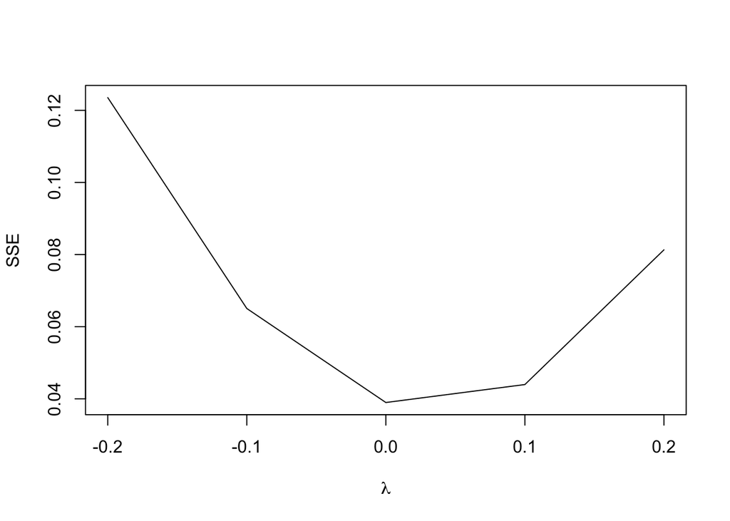

```r
bc
```

```
##   lambda        SSE
## 1   -0.2 0.12353047
## 2   -0.1 0.06505067
## 5    0.0 0.03897303
## 3    0.1 0.04396062
## 4    0.2 0.08131793
```

From this graph and table we see when $\lambda = 0$ we obtain the minimum SSE, which suggests us to apply log function to $Y$.

#### 3.23

Since our model has no intercept $\beta_0$, our reduced model should be $Y_{ij}=\beta_1X_j+\epsilon_{ij}$

Our full model should be $Y_{ij}=\mu_j+\epsilon_{ij}$

$df_F = n-c=20-10=10$, $df_R=n-1=20-1=19$

#### 4.14.a

```r
data2<-read.table("/Users/gehuazhang/Desktop/Data\ Sets/Chapter\ \ 1\ Data\ Sets/CH01PR19.txt")
colnames(data2)<-c("GPA","ACT")
origin_fit<-lm(GPA~0+ACT,data=data2)
origin_fit
```

```
##
## Call:
## lm(formula = GPA ~ 0 + ACT, data = data2)
##
## Coefficients:
##    ACT
## 0.1216
```

Origin fit: $Y_i=0.1216X_i$

#### 4.14.b

```r
confint(origin_fit,"ACT",level=0.95)
```

```
##         2.5 %    97.5 %
## ACT 0.1164216 0.1268643
```

With 95% of probability that our estimated $\beta_1$ would be in range 0.1164216 and 0.1268643.

#### 4.14.c

```r
ACT<-data2$ACT
predict.lm(origin_fit,newdata=data.frame(ACT=30),interval="confidence",level=0.95)
```

```
##        fit      lwr      upr
## 1 3.649287 3.492647 3.805928
```

The confidence interval for ACT=30 students’ GPA is 3.492647 and 3.805928.

#### 4.15.a

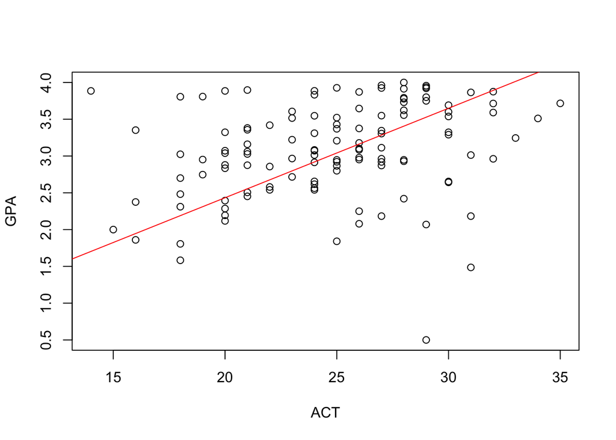

```r
plot(data2$ACT,data2$GPA, xlab="ACT", ylab="GPA")
abline(origin_fit,col="red")
```

This looks like a not bad fit, but the original data does not seem to have a linear relation.

#### 4.15.b

```r
resi<-origin_fit$resi
resi[1:10]
```

```
##           1           2           3           4           5           6
##  1.34249899  2.18199933  0.37199865 -0.13614392  0.47349899  0.09406994
##           7           8           9          10
## -0.93057297  0.67664156 -3.02764425  0.01528446
```

```r
sum(resi)
```

```
## [1] 7.9715
```

Residuals are not summing to zero.

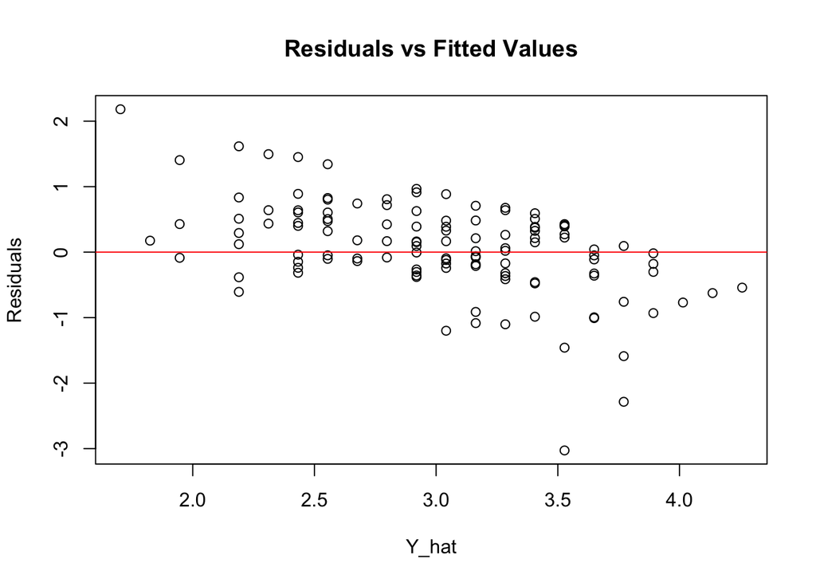

```r
plot(predict(origin_fit),resi,xlab="Y_hat",ylab="Residuals",main="Residuals vs Fitted Values")
abline(0,0,col="red")
```

The residuals of our model seems have a decreasing tendency over fitting values. They could be dependent, we need a further analysis about the dependencies of residuals and fitted values.

#### 4.15.c

```r
full2=lm(GPA~0+factor(ACT), data=data2)
summary(full2)$df
```

```
## [1] 21 99 21
```

```r
anova(origin_fit, full2)
```

```
## Analysis of Variance Table
##
## Model 1: GPA ~ 0 + ACT
## Model 2: GPA ~ 0 + factor(ACT)
##   Res.Df    RSS Df Sum of Sq      F    Pr(>F)
## 1    119 62.670
## 2     99 39.332 20    23.338 2.9371 0.0002159 ***
## ---
## Signif. codes:  0 '***' 0.001 '**' 0.01 '*' 0.05 '.' 0.1 ' ' 1
```

```r
qf(1-0.005,20,99)
```

```
## [1] 2.229389
```

Our null hypothesis and alternative:

$$H_0: E(Y) = \beta_1*X$$

$$H_a: E(Y) \neq \beta_1*X$$

Since $F^*>F$ we reject null hypothesis and conclude that this is not a good fit. The p-value in our test is 0.0002159, which is smaller than our test $\alpha=0.005$.